# Prediction Assignment Project

Sherby509

3/16/2021

1- SUMMARY Here is the final report of a project related to the practical machine learning course. This report aims to predict how 6 participants who have completed the exercises previously established and also to allow answering some questions of a quiz related to the course.This report will describing how we built our model, how we used cross validation, what we think the expected out of sample error is, and why we made the choices we did. we will also use our prediction model to predict 20 different test cases. 2-BACKGROUND Using devices such as Jawbone Up, Nike FuelBand, and Fitbit it is now possible to collect a large amount of data about personal activity relatively inexpensively. These type of devices are part of the quantified self movement – a group of enthusiasts who take measurements about themselves regularly to improve their health, to find patterns in their behavior, or because they are tech geeks. One thing that people regularly do is quantify how much of a particular activity they do, but they rarely quantify how well they do it. In this project, your goal will be to use data from accelerometers on the belt, forearm, arm, and dumbell of 6 participants. They were asked to perform barbell lifts correctly and incorrectly in 5 different ways. here is the link for the training and the test data: [Training Set]https://d396qusza40orc.cloudfront.net/predmachlearn/pml-training.csv [Test Set]https://d396qusza40orc.cloudfront.net/predmachlearn/pml-testing.csv

Let us load some packages

```r
library(knitr)
library(rpart)
library(rpart.plot)
library(caret)
library(rattle)
library(corrplot)
library(lattice)
library(ggplot2)
```

```r
library(randomForest)
```

# Let’s set a seed

```r
set.seed(1813)
```

Now let’s load the data from the links above

```r
Train <- "https://d396qusza40orc.cloudfront.net/predmachlearn/pml-training.csv"
Test  <- "https://d396qusza40orc.cloudfront.net/predmachlearn/pml-testing.csv"
Train_Data <- read.csv(url(Train), strip.white = TRUE, na.strings = c("NA",""))
Test_Data  <- read.csv(url(Test),  strip.white = TRUE, na.strings = c("NA",""))
```

# Let’s see the dimension of each of them

```r
dim(Train_Data)
```

```
## [1] 19622   160
```

```r
dim(Test_Data)
```

```
## [1]  20 160
```

# Let’s create a partition using caret with the training dataset (ratio: 70,30)

```r
Train_Part<- createDataPartition(Train_Data$classe, p=0.7, list=FALSE)
Train_set <- Train_Data[ Train_Part, ]
Test_set  <- Train_Data[-Train_Part, ]
```

# Let’s see the dimension of each of them once again

```r
dim(Train_set)
```

```
## [1] 13737   160
```

```r
dim(Test_set)
```

```
## [1] 5885  160
```

Both datasets contain NA values as well as near-zero-variance (NZV) variables. Let’s remove the NZV and their identifying variables. # variables with Nearly Zero Variance

```r
VAR_NZV <- nearZeroVar(Train_set)
Train_set <- Train_set[, -VAR_NZV]
Test_set  <- Test_set[, -VAR_NZV]
```

```r
dim(Train_set)
```

```
## [1] 13737   125
```

```r
dim(Test_set)
```

```
## [1] 5885  125
```

# variables containing NA

```r
VAR_NA <- sapply(Train_set, function(x) mean(is.na(x))) > 0.95
Train_set <- Train_set[ , VAR_NA == FALSE]
Test_set  <- Test_set [ , VAR_NA == FALSE]
```

```r
dim(Train_set)
```

```
## [1] 13737    59
```

```r
dim(Test_set)
```

```
## [1] 5885   59
```

we’re already down to 59 variables from 160. Now as the first 5 variables are identifiers and they won’t be useful for prediction, so get rid of those

```r
Train_set <- Train_set[ , -(1:5)]
Test_set  <- Test_set [ , -(1:5)]
```

```r
dim(Train_set)
```

```
## [1] 13737    54
```

```r
dim(Test_set)
```

```
## [1] 5885   54
```

Now we reduce the number of variable from 160 to 54. We can perform a correlation analysis between the variables.

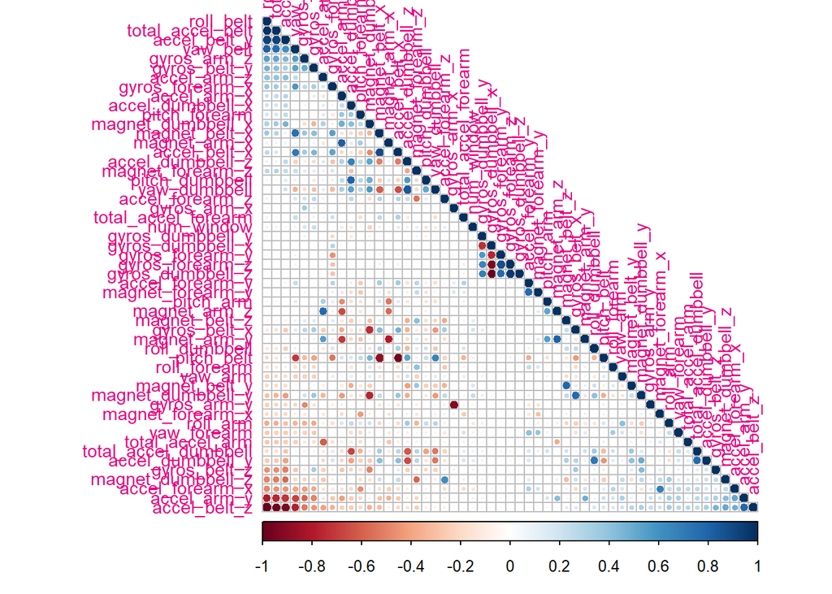

```r
COREL_Matrix <- cor(Train_set[ , -54])
corrplot(COREL_Matrix, order = "FPC", method = "circle", type = "lower",
         tl.cex = 0.9, tl.col =rgb(0.9, 0, 0.5))
```

As indicated in the graph above, it should be noted that the variables that are strongly correlated are indicated in dark colors as positive or negative correlation in respectively dark blue or dark red. Now We’ll build three (3) models: a Random Forest,a Decision Tree and a Generalized Boosted Model: 1-Random Forest # Model fit

```r
library(e1071)
set.seed(1813)
Random_For <- trainControl(method="repeatedcv", number=3,repeats = 2, verboseIter=FALSE)
modFitRandForest <- train(classe ~ ., data=Train_set, method="rf",
                          trControl=Random_For)
modFitRandForest$finalModel
```

```
##
## Call:
##  randomForest(x = x, y = y, mtry = param$mtry)
##                Type of random forest: classification
##                      Number of trees: 500
## No. of variables tried at each split: 27
##
##         OOB estimate of  error rate: 0.2%
## Confusion matrix:
##      A    B    C    D    E  class.error
## A 3904    1    0    0    1 0.0005120328
## B    3 2650    5    0    0 0.0030097818
## C    0    5 2391    0    0 0.0020868114
## D    0    0    7 2245    0 0.0031083481
## E    0    0    0    5 2520 0.0019801980
```

# Prediction on the Test_set

```r
Pred_RandF <- predict(modFitRandForest, newdata=Test_set)
```

```r
Conf_MatRandF <- confusionMatrix(Pred_RandF, as.factor(Test_set$classe))
```

```r
Conf_MatRandF
```

```
## Confusion Matrix and Statistics
##
##           Reference
## Prediction    A    B    C    D    E
##          A 1674    3    0    0    0
##          B    0 1134    2    0    0
##          C    0    1 1024    2    0
##          D    0    1    0  961    4
##          E    0    0    0    1 1078
##
## Overall Statistics
##
##                Accuracy : 0.9976
##                  95% CI : (0.996, 0.9987)
##     No Information Rate : 0.2845
##     P-Value [Acc > NIR] : < 2.2e-16
##
##                   Kappa : 0.997
##
##  Mcnemar's Test P-Value : NA
##
## Statistics by Class:
##
##                      Class: A Class: B Class: C Class: D Class: E
## Sensitivity            1.0000   0.9956   0.9981   0.9969   0.9963
## Specificity            0.9993   0.9996   0.9994   0.9990   0.9998
## Pos Pred Value         0.9982   0.9982   0.9971   0.9948   0.9991
## Neg Pred Value         1.0000   0.9989   0.9996   0.9994   0.9992
## Prevalence             0.2845   0.1935   0.1743   0.1638   0.1839
## Detection Rate         0.2845   0.1927   0.1740   0.1633   0.1832
## Detection Prevalence   0.2850   0.1930   0.1745   0.1641   0.1833
## Balanced Accuracy      0.9996   0.9976   0.9987   0.9979   0.9980
```

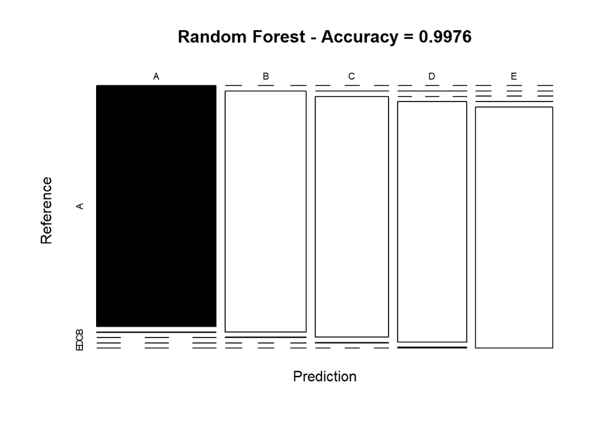

```r
plot(Conf_MatRandF$table, col = Conf_MatRandF$byClass,
     main = paste("Random Forest - Accuracy =",
                  round(Conf_MatRandF$overall['Accuracy'], 4)))
```

2-Decision Tree Model

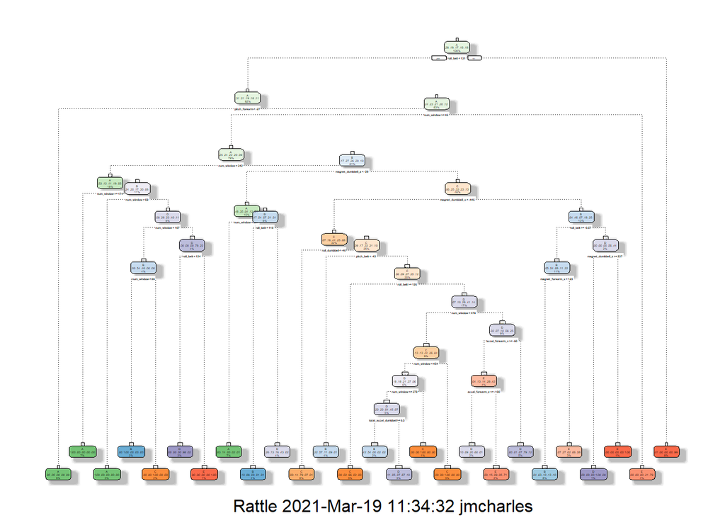

```r
set.seed(1813)
Dec_Tree_Mod <- rpart(classe ~ ., data = Train_set, method="class")
fancyRpartPlot(Dec_Tree_Mod)
```

# Let’sprediction on Test dataset

```r
Dec_Tree_Pred <- predict(Dec_Tree_Mod, newdata = Test_set, type="class")
Dec_Tree_Matrix <- confusionMatrix(Dec_Tree_Pred, as.factor(Test_set$classe))
Dec_Tree_Matrix
```

```
## Confusion Matrix and Statistics
##
##           Reference
## Prediction    A    B    C    D    E
##          A 1411   94    2    8    6
##          B  158  888   71   87   46
##          C    1   51  859   36    2
##          D   90   54   84  773   81
##          E   14   52   10   60  947
##
## Overall Statistics
##
##                Accuracy : 0.8289
##                  95% CI : (0.819, 0.8384)
##     No Information Rate : 0.2845
##     P-Value [Acc > NIR] : < 2.2e-16
##
##                   Kappa : 0.7843
##
##  Mcnemar's Test P-Value : < 2.2e-16
##
## Statistics by Class:
##
##                      Class: A Class: B Class: C Class: D Class: E
## Sensitivity            0.8429   0.7796   0.8372   0.8019   0.8752
## Specificity            0.9739   0.9237   0.9815   0.9372   0.9717
## Pos Pred Value         0.9277   0.7104   0.9052   0.7144   0.8744
## Neg Pred Value         0.9397   0.9458   0.9662   0.9602   0.9719
## Prevalence             0.2845   0.1935   0.1743   0.1638   0.1839
## Detection Rate         0.2398   0.1509   0.1460   0.1314   0.1609
## Detection Prevalence   0.2585   0.2124   0.1613   0.1839   0.1840
## Balanced Accuracy      0.9084   0.8517   0.9094   0.8695   0.9235
```

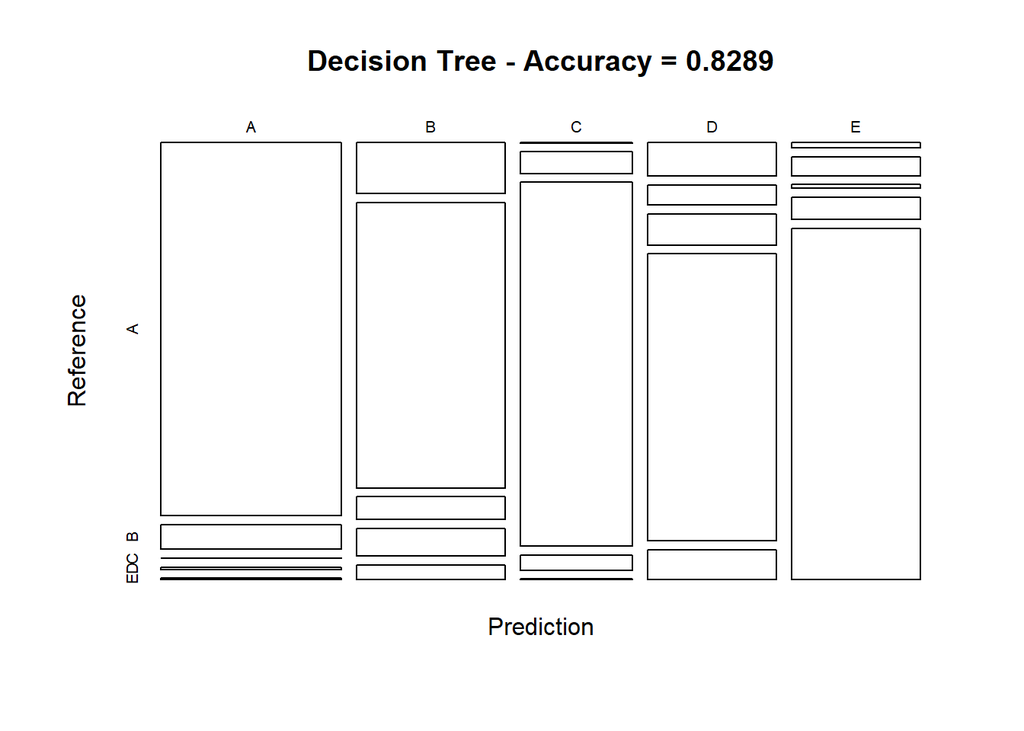

```r
plot(Dec_Tree_Matrix$table, col = Dec_Tree_Matrix$byClass,
     main = paste("Decision Tree - Accuracy =",
                  round(Dec_Tree_Matrix$overall['Accuracy'], 4)))
```

3-Generalized Boosted Model (GBM)

```r
library(gbm)
contr_GBM <- trainControl(method = "repeatedcv", number = 5, repeats = 1)
model_GBM  <- train(classe ~ ., data=Train_set, method = "gbm",
                    trControl = contr_GBM, verbose = FALSE)
```

```r
model_GBM$finalModel
```

```
## A gradient boosted model with multinomial loss function.
## 150 iterations were performed.
## There were 53 predictors of which 53 had non-zero influence.
```

# Let’s set the prediction on test dataset

```r
GBM_Predict <- predict(model_GBM, newdata=Test_set)
Mat_GBM_Conf <- confusionMatrix(GBM_Predict, as.factor(Test_set$classe))
Mat_GBM_Conf
```

```
## Confusion Matrix and Statistics
##
##           Reference
## Prediction    A    B    C    D    E
##          A 1672    8    0    1    0
##          B    2 1119    9    5    2
##          C    0   12 1017   11    2
##          D    0    0    0  947   16
##          E    0    0    0    0 1062
##
## Overall Statistics
##
##                Accuracy : 0.9884
##                  95% CI : (0.9854, 0.991)
##     No Information Rate : 0.2845
##     P-Value [Acc > NIR] : < 2.2e-16
##
##                   Kappa : 0.9854
##
##  Mcnemar's Test P-Value : NA
##
## Statistics by Class:
##
##                      Class: A Class: B Class: C Class: D Class: E
## Sensitivity            0.9988   0.9824   0.9912   0.9824   0.9815
## Specificity            0.9979   0.9962   0.9949   0.9967   1.0000
## Pos Pred Value         0.9946   0.9842   0.9760   0.9834   1.0000
## Neg Pred Value         0.9995   0.9958   0.9981   0.9965   0.9959
## Prevalence             0.2845   0.1935   0.1743   0.1638   0.1839
## Detection Rate         0.2841   0.1901   0.1728   0.1609   0.1805
## Detection Prevalence   0.2856   0.1932   0.1771   0.1636   0.1805
## Balanced Accuracy      0.9983   0.9893   0.9930   0.9896   0.9908
```

# Let’s plot the matrix results

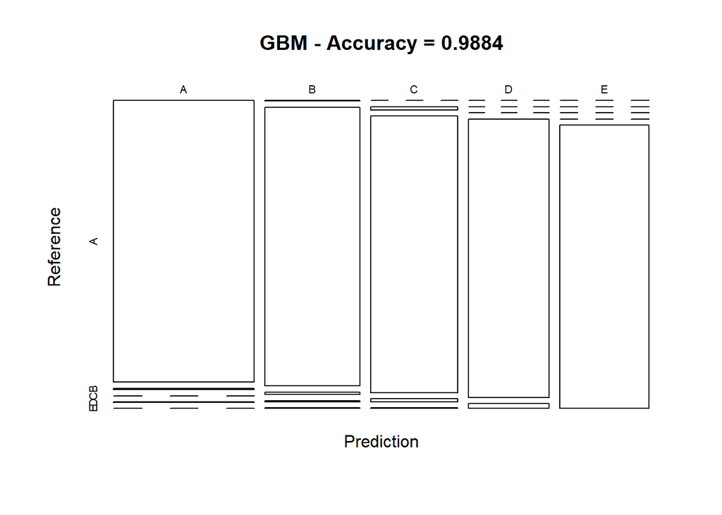

```r
plot(Mat_GBM_Conf$table, col = Mat_GBM_Conf$byClass,
     main = paste("GBM - Accuracy =", round(Mat_GBM_Conf$overall['Accuracy'], 4)))
```

As we can see it above, the predictive accuracy of the GBM is high at 98.84 %.

# In that case, the Random Forest model will be selected and be applied to make predictions on the 20 quiz results (Data Quiz) as shown below.

```r
Quiz_Prediction <- predict(modFitRandForest, newdata = Test_Data )
Quiz_Prediction
```

```
##  [1] B A B A A E D B A A B C B A E E A B B B
## Levels: A B C D E
```